# Assessing TP53 results at tumor purity threshold

SJ Spielman for CCDL

2023

This notebook was written as part of manuscript revisions. Here, we explore how TP53-related results might change if only tumors at a certain level of known tumor purity (`tumor_fraction` metadata variable) are considered. Only stranded RNA data is considered here, as in the manuscript.

The associated issue for this exploration is here: https://github.com/AlexsLemonade/OpenPBTA-analysis/issues/1624

## Functions

The chunk below defines a helper function used to convert an expression matrix into a data frame with relevant information, including TP53 status and cancer group.

```r
# Convert a FPKM matrix to log2-transformed-FPKM data frame for TP53
expression_matrix_to_df <- function(mat, status_df, metadata_df = metadata, palette_df = pal_df) {
  # mat is matrix of expression
  # status_df contains information about tp53 status and scores
  # metadata_df and palette_df are the metadata and histology palette data frames, respectively

  # Filter to TP53 expression only
  mat <- t(mat)[,"TP53"]

  # log2
  mat_log2 <- log2(mat + 1)

  # df
  mat_log2 %>%
    tibble::as_tibble(rownames = "Kids_First_Biospecimen_ID") %>%
    dplyr::rename(tp53_fpkm = value) %>%
    # join in tp53 status and scores
    dplyr::inner_join(
      dplyr::select(
        status_df,
        Kids_First_Biospecimen_ID,
        tp53_score,
        tp53_altered),
        by = "Kids_First_Biospecimen_ID"
    ) %>%

    # join in cancer group
    dplyr::inner_join(
      dplyr::select(
        metadata,
        Kids_First_Biospecimen_ID,
        cancer_group),
        by = "Kids_First_Biospecimen_ID"
    ) %>%
    # join in palette
    dplyr::left_join(palette_df, by = "cancer_group")
}
```

The chunk below defines a helper function to plot TP53 score or expression across status.

```r
plot_tp53_status <- function(df, var, y_lab) {
  # df is a data frame with all relevant information
  # var is the numeric variable of interest to plot across tp53 status
  # y_lab is y-axis label

  # Prepare stats df for median +/ IQR of the given `var`
  stats_df <- df %>%
    dplyr::group_by(tp53_altered) %>%
    dplyr::summarize(
      y = median({{var}}, na.rm=TRUE),
      ymin = quantile({{var}}, 0.25, na.rm=TRUE),
      ymax = quantile({{var}}, 0.75, na.rm=TRUE)
    )

  # Make/return plot
  ggplot(df) +
    aes(x = tp53_altered,
        y = {{var}}) +
    geom_violin() +
    geom_jitter(
      alpha = 0.25,
      width = 0.1,
      size = 1
    ) +
    # Add median +/- IQR pointrange
    geom_pointrange(data = stats_df,
                    aes(x = tp53_altered, y = y, ymin = ymin, ymax = ymax),
                    color = "firebrick") +
    labs(
      x = "TP53 altered status",
      y = y_lab
    )
}
```

## Files and directories

```r
# pipe and plot theme
`%>%` <- dplyr::`%>%`
library(ggplot2)
theme_set(ggpubr::theme_pubr())

set.seed(1234)

root_dir <- rprojroot::find_root(rprojroot::has_dir(".git"))
analysis_dir <- file.path(root_dir, "analyses")
data_dir <- file.path(root_dir, "data")

tp53_dir <- file.path(analysis_dir, "tp53_nf1_score")

# source function to plot ROC curve
source(file.path(tp53_dir, "util", "plot_roc.R"))

# result directories
results_dir_full <- file.path(tp53_dir, "results")
results_dir_threshold <- file.path(results_dir_full, "tumor-purity-threshold")

# output plot data CSV files for Zenodo upload
figS7d_csv <- file.path(results_dir_threshold, "figure-S7d-data.csv")
figS7e_csv <- file.path(results_dir_threshold, "figure-S7e-data.csv")
figS7f_csv <- file.path(results_dir_threshold, "figure-S7f-data.csv")


# output plots
tp53_roc_pdf <- file.path(results_dir_threshold, "tp53-roc_tumor-purity-threshold.pdf")
tp53_score_status_pdf <- file.path(results_dir_threshold, "tp53-score-status_tumor-purity-threshold.pdf")
tp53_fpkm_status_pdf <- file.path(results_dir_threshold, "tp53-fpkm-status_tumor-purity-threshold.pdf")
tp53_cancer_groups_pdf <- file.path(results_dir_threshold, "tp53-cancer-groups_tumor-purity-threshold.pdf")
```

Read and prepare input files:

```r
# metadata file
metadata <- readr::read_tsv(file.path(root_dir,
                                      "data",
                                      "pbta-histologies.tsv"),
                            guess_max = 10000)
# palette file
pal_dir <- file.path(
  root_dir,
  "figures",
  "palettes"
)

pal_df <- readr::read_tsv(
 file.path(
   pal_dir,
   "broad_histology_cancer_group_palette.tsv")
) %>%
  dplyr::select(cancer_group, cancer_group_display, cancer_group_hex)
# binary palette file
binary_pal <- readr::read_tsv(
  file.path(pal_dir, "binary_color_palette.tsv")) %>%
  # remove `na_color`
  dplyr::filter(color_names != "na_color")
# ROC score files -----
# original files:
roc_file_stranded_original <- readr::read_tsv(
  file.path(results_dir_full, "stranded_TP53_roc_threshold_results.tsv")
)
roc_file_stranded_shuff_original <- readr::read_tsv(
  file.path(results_dir_full, "stranded_TP53_roc_threshold_results_shuffled.tsv")
)
# tumor purity thresholded files:
roc_file_stranded_thresholded <- readr::read_tsv(
  file.path(results_dir_threshold,
            "stranded_tumor-purity-threshold_TP53_roc_threshold_results.tsv")
)
roc_file_stranded_shuff_thresholded <- readr::read_tsv(
  file.path(results_dir_threshold,
            "stranded_tumor-purity-threshold_TP53_roc_threshold_results_shuffled.tsv")
)
## Status files -----

status_original <- readr::read_tsv(
    file.path(results_dir_full, "tp53_altered_status.tsv")
  ) %>%
  dplyr::rename(Kids_First_Biospecimen_ID = Kids_First_Biospecimen_ID_RNA) %>%
  # Filter down to stranded only
  dplyr::inner_join(
    dplyr::select(metadata,
                  Kids_First_Biospecimen_ID,
                  RNA_library)
  ) %>%
  dplyr::filter(RNA_library=="stranded")
# this is already only stranded
status_thresholded <- readr::read_tsv(
  file.path(results_dir_threshold,
            "tp53_altered_status_tumor-purity-threshold.tsv")
  ) %>%
  dplyr::rename(Kids_First_Biospecimen_ID = Kids_First_Biospecimen_ID_RNA)
## Expression data ------
stranded_expression <- readr::read_rds(
  file.path(data_dir,
            "pbta-gene-expression-rsem-fpkm-collapsed.stranded.rds")
)
```

The expression data needs a second version filtered to the thresholded set:

```r
# Create a second version of this with only tumor-purity passing samples
# Define path to tumor purity module
tumor_purity_dir <- file.path(
  analysis_dir,
  "tumor-purity-exploration"
)

# Define path to metadata file which has been filtered to only biospecimens that
#  survive the cancer-group-level threshold
tumor_purity_file <- file.path(
  tumor_purity_dir,
  "results",
  "thresholded_rna_stranded_same-extraction.tsv"
)

# Load the function to filter IDs
source(
  file.path(tumor_purity_dir, "util", "function_filter-by-threshold.R")
)

# Filter the expression data
stranded_expression_thresholded <- filter_expression_by_tumor_purity(stranded_expression,
                                                                     tumor_purity_file)
# Convert both to dfs, and join with tp53 status
tp53_df <- expression_matrix_to_df(stranded_expression, status_original)
tp53_thresholded_df <- expression_matrix_to_df(stranded_expression_thresholded, status_thresholded)
```

## Re-analysis 1: ROC curves

In the manuscript, we found:

https://github.com/AlexsLemonade/OpenPBTA-manuscript/blob/b0fdf6f24fe9c021f22e8b7da348708f68877ee5/content/03.results.md?plain=1#L194

> The classifier achieved a high accuracy (AUROC = 0.85) for rRNA-depleted, stranded samples compared to randomly shuffled *TP53* scores (**Figure {@fig:Fig4}A**).

First, here’s the original ROC presented in the manuscript

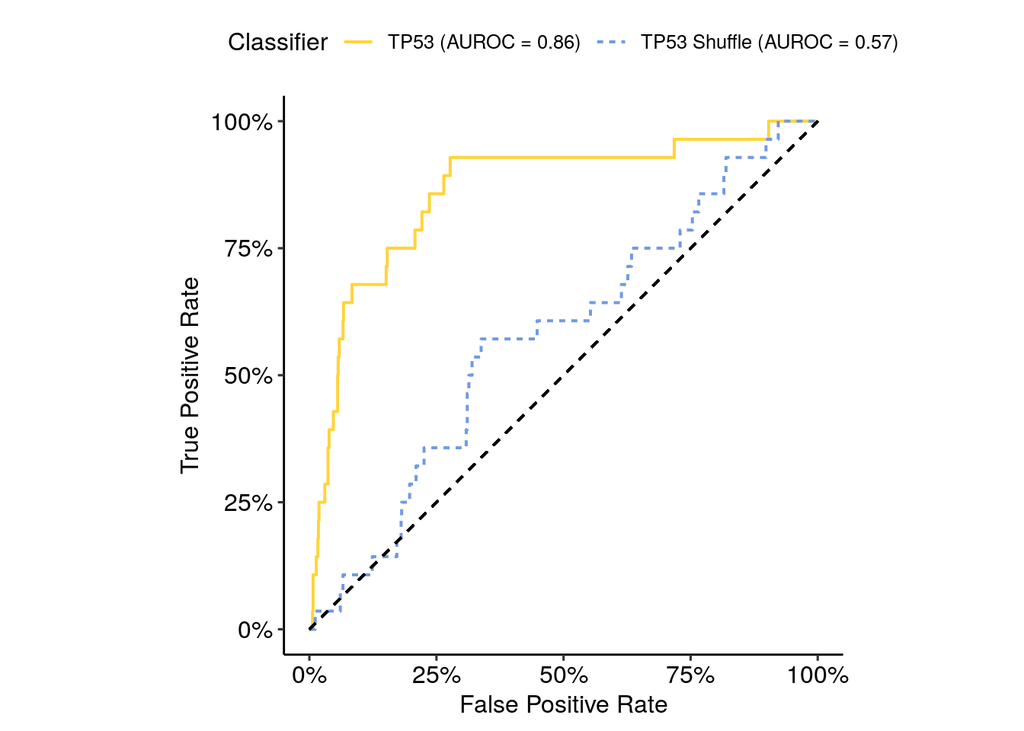

```r
plot_roc(roc_df = dplyr::bind_rows(roc_file_stranded_original,
                                   roc_file_stranded_shuff_original),
         # the next 2 path args don't matter since export is FALSE
         plots_dir,
         fname = "",
         export = FALSE)
```

Now, here is the new ROC generated from thresholded data:

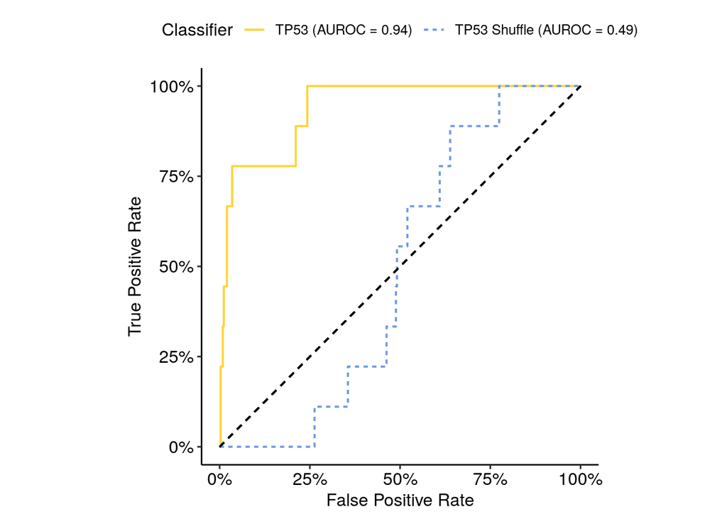

```r
roc_df <- dplyr::bind_rows(roc_file_stranded_thresholded,
                           roc_file_stranded_shuff_thresholded)
new_roc <- plot_roc(roc_df,
                    # the next 2 path args don't matter since export is FALSE
                    plots_dir,
                    fname = "",
                    export = FALSE)
new_roc
```

The classifier performance follows a similar trend to previous results. Shuffled (randomized) data for both versions of the data produced an AUC around 0.5, indicating performance is no different from a random classifier as expected. Thresholded data produced an AUC=0.94 which is very high, as is the original analysis which produced AUC=0.86.

Here we’ll export this new ROC curve:

```r
# Update colors and line style to match manuscript before export
new_roc <- new_roc +
  scale_color_manual(name = "", values = binary_pal$hex_codes) +
  scale_linetype_manual(name = "", values = c("solid", "solid")) +
  theme(
    legend.text = element_text(size = 9)
  )
```

[output not shown]

```r
ggsave(tp53_roc_pdf,
       new_roc,
       width = 4.5,
       height = 4,
       # needed for compilation
       useDingbats = FALSE)
```

We’ll also export this plot’s data:

```r
roc_df %>%
  # this column is just tp53
  dplyr::select(-gene) %>%
  readr::write_csv(figS7d_csv)
```

## Re-analysis 2: TP53 scores between “activated” and “lost” tumors.

In the manuscript, we found:

https://github.com/AlexsLemonade/OpenPBTA-manuscript/blob/b0fdf6f24fe9c021f22e8b7da348708f68877ee5/content/03.results.md?plain=1#L197

> While we expected that samples annotated as “lost” would have higher *TP53* scores than would samples annotated as “other,” we observed that samples annotated as “activated” had similar *TP53* scores to those annotated as “lost” (**Figure {@fig:Fig4}B**, Wilcoxon p = 0.23).

Previously, we observed the following:

```r
# Wilcoxon:
wilcox.test(
 tp53_df$tp53_score[tp53_df$tp53_altered == "loss"],
 tp53_df$tp53_score[tp53_df$tp53_altered == "activated"]
)
```

```
    Wilcoxon rank sum test with continuity correction

data:  tp53_df$tp53_score[tp53_df$tp53_altered == "loss"] and tp53_df$tp53_score[tp53_df$tp53_altered == "activated"]
W = 562, p-value = 0.9532
alternative hypothesis: true location shift is not equal to 0
```

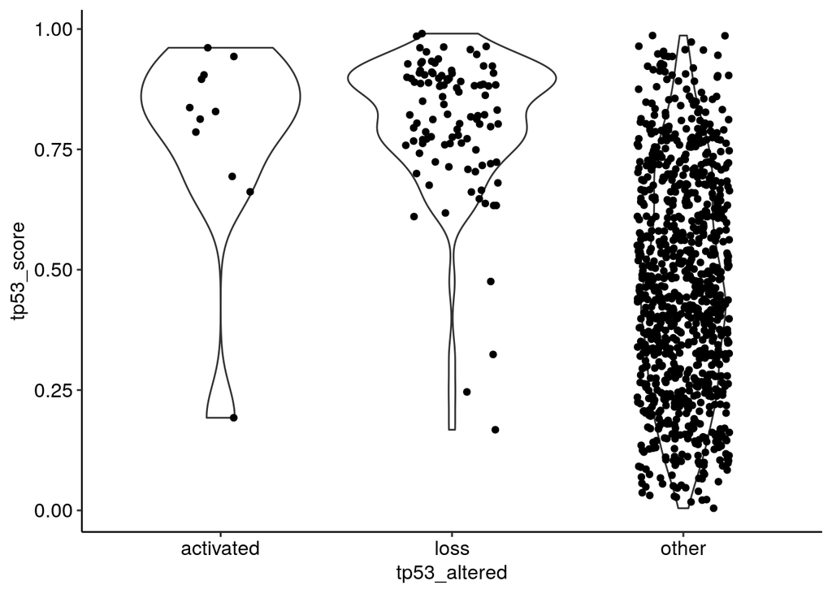

```r
# violin/jitter plot:
ggplot(tp53_df) +
  aes(x = tp53_altered,
      y = tp53_score) +
  geom_violin() +
  geom_jitter(width = 0.2)
```

Notably, something is up with this P-value - we reported 0.23 in the text, but it seems that was based on an outdated figure.

- Here is the figure we submitted https://github.com/AlexsLemonade/OpenPBTA-manuscript/blob/33c98980d39dfc8b6c63691c819f8140f349c149/content/images/main/Figure4.png (April 2022)
- Here is the figure panel PDF and compiled PNG versions in the analysis repo:
  - Panel: https://github.com/AlexsLemonade/OpenPBTA-analysis/blob/e4244a104183e5223bc5297df938f8b5e6c7ef22/figures/pdfs/fig4/panels/tp53_scores_by_altered_panel.pdf (July 2022)
  - PNG: https://github.com/AlexsLemonade/OpenPBTA-analysis/blob/e4244a104183e5223bc5297df938f8b5e6c7ef22/figures/pngs/figure4.png (July 2022)

Now, we observe:

```r
# Wilcoxon:
wilcox.test(
 tp53_thresholded_df$tp53_score[tp53_thresholded_df$tp53_altered == "loss"],
 tp53_thresholded_df$tp53_score[tp53_thresholded_df$tp53_altered == "activated"]
)
```

```
    Wilcoxon rank sum test

data:  tp53_thresholded_df$tp53_score[tp53_thresholded_df$tp53_altered ==  and tp53_thresholded_df$tp53_score[tp53_thresholded_df$tp53_altered ==     "loss"] and     "activated"]
W = 86, p-value = 0.2824
alternative hypothesis: true location shift is not equal to 0
```

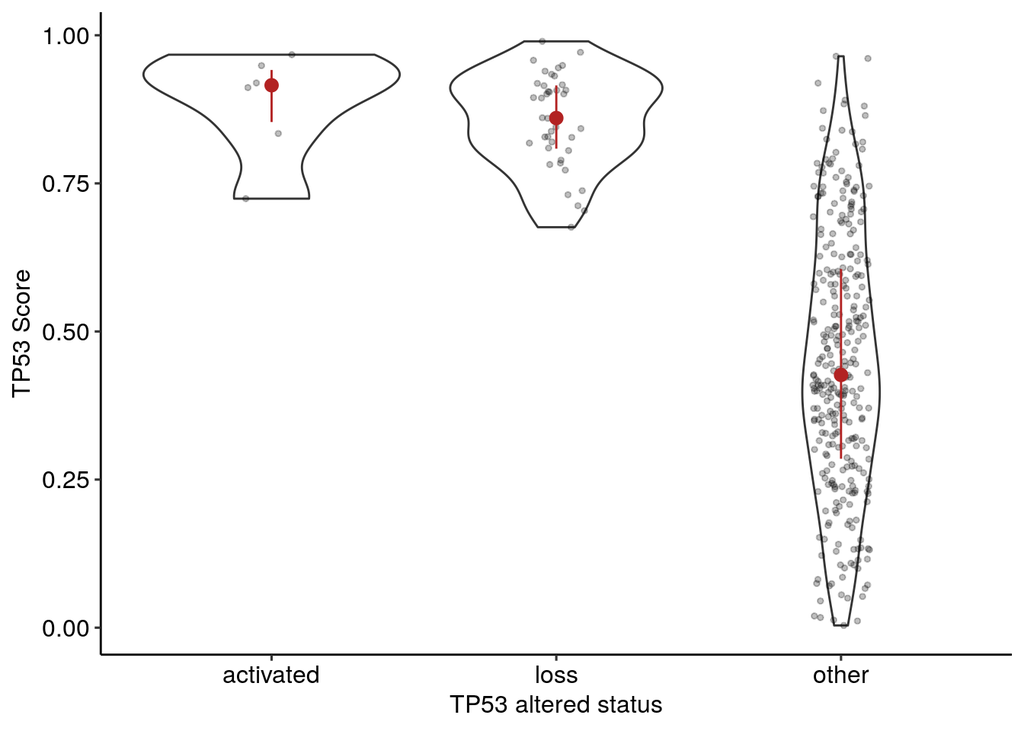

```r
# violin/jitter plot:
# save to variable and style in preparation for export
score_plot <- plot_tp53_status(tp53_thresholded_df, tp53_score, "TP53 Score")

score_plot
```

We’ll export the thresholded version of this plot, `score_plot`:

```r
ggsave(
  tp53_score_status_pdf,
  score_plot,
  width = 4,
  height = 4,
  # needed for compilation
  useDingbats = FALSE
)
```

We’ll also export this plot’s data:

```r
tp53_thresholded_df %>%
  # clean up columns
  dplyr::select(Kids_First_Biospecimen_ID, dplyr::everything(),
                -cancer_group_hex, -tp53_fpkm) %>%
  # arrange on biospecimen
  dplyr::arrange(Kids_First_Biospecimen_ID) %>%
  readr::write_csv(figS7e_csv)
```

## Re-analysis 3: TP53 expression between “activated” and “lost” tumors.

In the manuscript, we found:

https://github.com/AlexsLemonade/OpenPBTA-manuscript/blob/b0fdf6f24fe9c021f22e8b7da348708f68877ee5/content/03.results.md?plain=1#L199

> Moreover, tumors with “activating” *TP53* mutations showed higher *TP53* expression compared to those with *TP53* “loss” mutations (Wilcoxon p = 3.5e-3, **Figure {@fig:Fig4}C**).

Previously, we observed the following:

```r
# Wilcoxon:
wilcox.test(
 tp53_df$tp53_fpkm[tp53_df$tp53_altered == "loss"],
 tp53_df$tp53_fpkm[tp53_df$tp53_altered == "activated"]
)
```

```
    Wilcoxon rank sum test with continuity correction

data:  tp53_df$tp53_fpkm[tp53_df$tp53_altered == "loss"] and tp53_df$tp53_fpkm[tp53_df$tp53_altered == "activated"]
W = 271, p-value = 0.005493
alternative hypothesis: true location shift is not equal to 0
```

```r
# Medians:
tp53_df %>%
  dplyr::group_by(tp53_altered) %>%
  dplyr::summarize(median_tp53 = median(tp53_fpkm)) %>%
  dplyr::arrange(-median_tp53)
```

| tp53_altered | median_tp53 |
| --- | --- |
| activated | 5.179909 |
| other | 4.238787 |
| loss | 3.936402 |

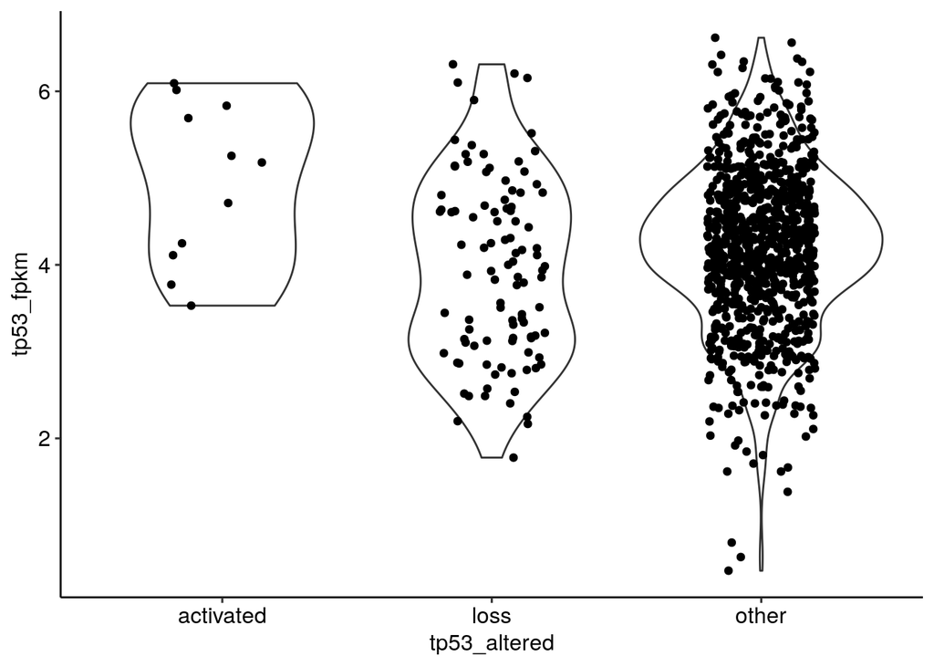

```r
# violin/jitter plot:
ggplot(tp53_df) +
  aes(x = tp53_altered,
               y = tp53_fpkm) +
  geom_violin() +
  geom_jitter(width = 0.2)
```

The above P-value (0.006) has the same issue as in re-analysis 2 - it needs to be updated in the text, but it is correct in the most up-to-date figure (Panel C: https://github.com/AlexsLemonade/OpenPBTA-analysis/blob/e4244a104183e5223bc5297df938f8b5e6c7ef22/figures/pngs/figure4.png).

After thresholding, we now observe:

```r
# Wilcoxon:
wilcox.test(
 tp53_thresholded_df$tp53_fpkm[tp53_thresholded_df$tp53_altered == "loss"],
 tp53_thresholded_df$tp53_fpkm[tp53_thresholded_df$tp53_altered == "activated"]
)
```

```
    Wilcoxon rank sum test

data:  tp53_thresholded_df$tp53_fpkm[tp53_thresholded_df$tp53_altered ==  and tp53_thresholded_df$tp53_fpkm[tp53_thresholded_df$tp53_altered ==     "loss"] and     "activated"]
W = 31, p-value = 0.002115
alternative hypothesis: true location shift is not equal to 0
```

```r
# Medians:
tp53_thresholded_df %>%
  dplyr::group_by(tp53_altered) %>%
  dplyr::summarize(median_tp53 = median(tp53_fpkm)) %>%
  dplyr::arrange(-median_tp53)
```

| tp53_altered | median_tp53 |
| --- | --- |
| activated | 5.762312 |
| other | 4.150558 |
| loss | 3.991839 |

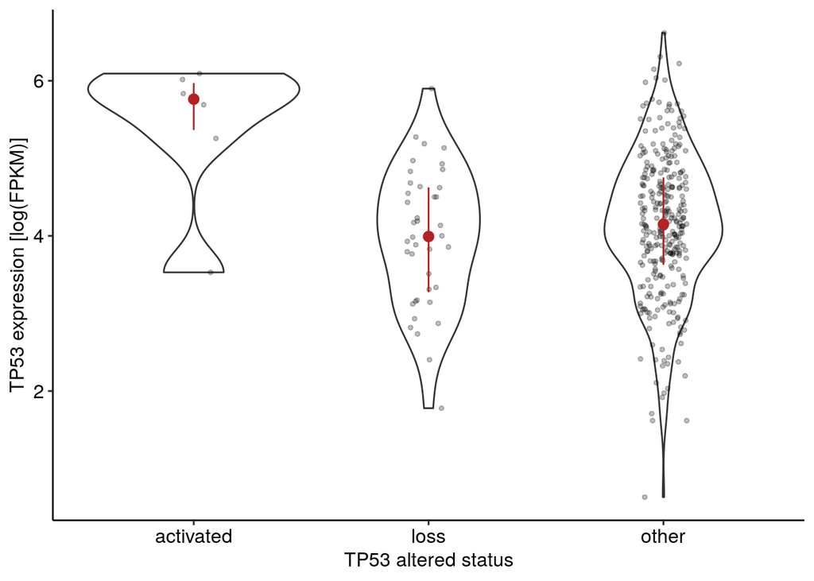

```r
# violin/jitter plot:
# save to variable and style in preparation for export
fpkm_plot <- plot_tp53_status(tp53_thresholded_df, tp53_fpkm, "TP53 expression [log(FPKM)]")

fpkm_plot
```

These results are consistent - TP53 “activated” samples have signficantly higher expression than do “lost” samples.

We’ll export the thresholded version of this plot, `fpkm_plot`:

```r
ggsave(
  tp53_fpkm_status_pdf,
  fpkm_plot,
  width = 4,
  height = 4,
  # needed for compilation
  useDingbats = FALSE
)
```

We’ll also export this plot’s data:

```r
tp53_thresholded_df %>%
  # clean up columns
  dplyr::select(Kids_First_Biospecimen_ID, dplyr::everything(),
                -cancer_group_hex, -tp53_score) %>%
  # arrange on biospecimen
  dplyr::arrange(Kids_First_Biospecimen_ID) %>%
  readr::write_csv(figS7f_csv)
```

## Re-analysis 4: Distribution of TP53 scores among cancer groups

In the manuscript, we found:

https://github.com/AlexsLemonade/OpenPBTA-manuscript/blob/b0fdf6f24fe9c021f22e8b7da348708f68877ee5/content/03.results.md?plain=1#L200

> Tumor types with the highest median *TP53* scores were those known to harbor somatic *TP53* alterations and included DMGs, medulloblastomas, HGGs, DNETs, ependymomas, and craniopharyngiomas (**Figure {@fig:Fig4}D**), while gangliogliomas, LGGs, meningiomas, and schwannomas had the lowest median scores.

Previously we observed:

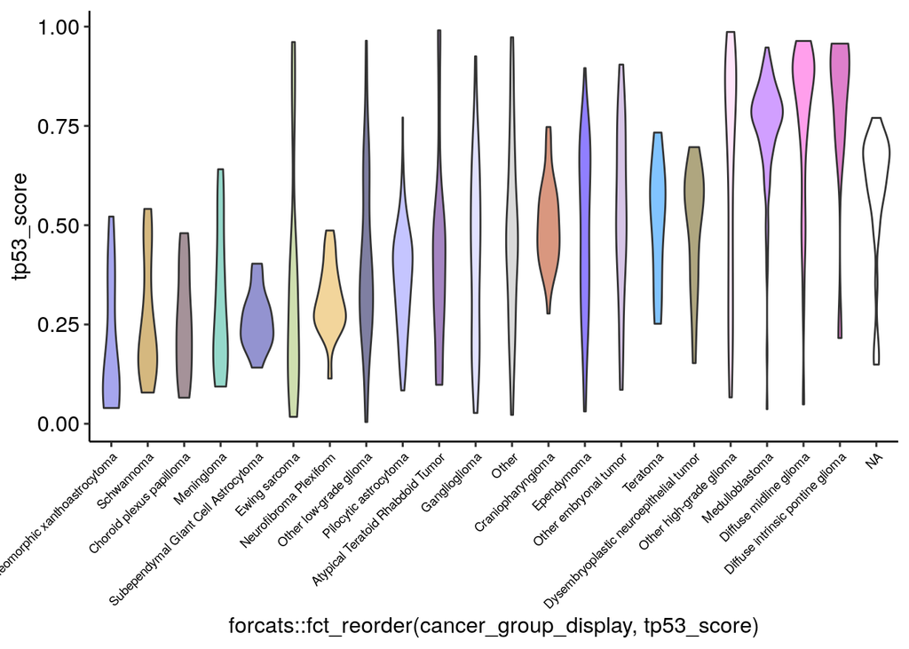

```r
ggplot(tp53_df) +
  aes(x = forcats::fct_reorder(cancer_group_display, tp53_score),
               y = tp53_score,
               fill = cancer_group_hex) +
  geom_violin(alpha = 0.5) +
  stat_summary(fun.y = "median") +
  scale_fill_identity() +
  theme(
    axis.text.x = element_text(hjust = 1, angle = 45, size = 7)
  )
```

Now we observe:

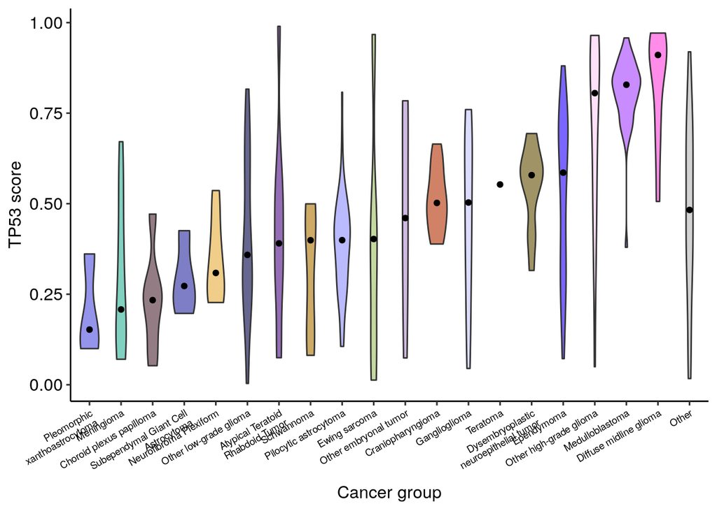

```r
# Format this plot for export:
tp53_violins <- tp53_thresholded_df %>%
  dplyr::mutate(
    cancer_group_display = stringr::str_wrap(cancer_group_display, 25),
    cancer_group_display = forcats::fct_reorder(cancer_group_display, tp53_score),
    cancer_group_display = forcats::fct_relevel(cancer_group_display, "Other", after = Inf)
  ) %>%
  # plot
  ggplot() +
    aes(x = cancer_group_display,
        y = tp53_score,
        fill = cancer_group_hex) +
  geom_violin(alpha = 0.6) +
  stat_summary(geom = "point",
               fun.y = "median") +
  scale_fill_identity() +
  labs(
    x = "Cancer group",
    y = "TP53 score"
  ) +
  theme(
    axis.text.x = element_text(hjust = 1, angle = 30, size = 7)
  )

tp53_violins
```

- Previously highest median groups are all still high (DMGs, medulloblastomas, HGGs, DNETs, ependymomas, and craniopharyngiomas).
- Previously lowest median groups are *mostly* still low (LGGs, meningiomas, and schwannomas) but Gangliomas now show a higher median value. These scores also have a very broad spread, and their overall distribution appears very similar to that previously observed.

As such, these results are broadly consistent.

Now we’ll export `tp53_violins`:

```r
ggsave(
  tp53_cancer_groups_pdf,
  tp53_violins,
  width = 8,
  height = 3.75
)
```

## Re-analysis 5: LFS patients

In the manuscript, we found:

https://github.com/AlexsLemonade/OpenPBTA-manuscript/blob/b0fdf6f24fe9c021f22e8b7da348708f68877ee5/content/03.results.md?plain=1#L203

> Indeed, we observed higher scores in LFS tumors (N = 8) for which we detected high-confidence *TP53* somatic alterations (**Tables S1 and S3**).

```r
status_original %>%
  tidyr::drop_na(tp53_score) %>%
  dplyr::mutate(lfs = cancer_predispositions == "Li-Fraumeni syndrome") %>%
  dplyr::group_by(lfs) %>%
  dplyr::summarize(n(),
                   median(tp53_score))
```

| lfs | n() | median(tp53_score) |
| --- | --- | --- |
| FALSE | 972 | 0.4737132 |
| TRUE | 9 | 0.9077460 |

Here we see there are 9 LFS samples, so it’s unclear where N=8 is from. This should be revisited.

Now, we observe:

```r
status_thresholded %>%
  tidyr::drop_na(tp53_score) %>%
  dplyr::mutate(lfs = cancer_predispositions == "Li-Fraumeni syndrome") %>%
  dplyr::group_by(lfs) %>%
  dplyr::summarize(n(),
                   median(tp53_score))
```

| lfs | n() | median(tp53_score) |
| --- | --- | --- |
| FALSE | 409 | 0.4948075 |
| TRUE | 4 | 0.8478773 |

Results are consistent - after thresholding, LFS samples still have higher scores compared to non-LFS samples.

## Re-analysis 6: Hypermutators

In the manuscript, we found:

https://github.com/AlexsLemonade/OpenPBTA-manuscript/blob/b0fdf6f24fe9c021f22e8b7da348708f68877ee5/content/03.results.md?plain=1#L227

> With one exception, hypermutant and ultra-hypermutant tumors had high *TP53* scores (> 0.5) and telomerase activity.

To confirm the above, we’ll first check the original TP53 scores of these samples.

First, figure out which samples these are:

```r
# These samples were identified as coming from hypermutators in the manuscript:
# https://github.com/AlexsLemonade/OpenPBTA-manuscript/blob/b0fdf6f24fe9c021f22e8b7da348708f68877ee5/content/03.results.md?plain=1#L232-L247
# These IDs are WGS, but do not include cell lines.
hypermutator_bs_ids <- c("BS_85Q5P8GF", "BS_P0QJ1QAH", "BS_20TBZG09", "BS_8AY2GM4G", "BS_02YBZSBY", "BS_VW4XN9Y7", "BS_F0GNWEJJ", "BS_P3PF53V8")

# Get the sample ids
original_sample_ids <- metadata %>%
  dplyr::filter(Kids_First_Biospecimen_ID %in% hypermutator_bs_ids) %>%
  dplyr::pull(sample_id) %>%
  unique()

status_original %>%
  dplyr::filter(sample_id %in% original_sample_ids) %>%
  dplyr::select(sample_id, Kids_First_Biospecimen_ID, tp53_score)
```

| sample_id | Kids_First_Biospecimen_ID | tp53_score |
| --- | --- | --- |
| 7316-2085 | BS_G3RJTBZD | 0.8839409 |
| 7316-2189 | BS_HJRTC9JQ | 0.6618956 |
| 7316-2189 | BS_PGK832G2 | 0.2460889 |
| 7316-2307 | BS_Z8YZ6QGS | 0.8957173 |
| 7316-2594 | BS_VF5XWFXD | 0.8910954 |
| 7316-2640 | BS_FX2P2WEG | 0.1924459 |
| 7316-3058 | BS_2A162JH9 | 0.7721751 |
| 7316-3058 | BS_D29RPBSZ | 0.8367765 |
| 7316-3058 | BS_BWBDH9GM | 0.7864010 |
| 7316-3311 | BS_VNWKNRY4 | 0.7544814 |

[output cut: 1 more lines]

Here, it appears that all but 2 tumors have scores >0.5 (`sample_id`s `7316-2189` and `7316-2640`). But, a different sample associated with `7316-2189` has a score >0.5, so this means indeed only 1 tumor has that lower score.

For thresholded comparison, as we found in this [tumor purity exploration notebook](https://github.com/AlexsLemonade/OpenPBTA-analysis/blob/78e4969b99b4ebbc22915b9d8b58b5b3f6a9cad5/analyses/tumor-purity-exploration/02_explore-tumor-purity-thresholds.Rmd), only two hypermutator samples are present in the thresholded set:

- `7316-3311` (`PT_EB0D3BXG`)
- `7316-2307` (`PT_S0Q27J13`)

```r
remaining_sample_ids <- c("7316-3311", "7316-2307")
status_thresholded %>%
  dplyr::filter(sample_id %in% remaining_sample_ids) %>%
  dplyr::pull(tp53_score)
```

```
[1] 0.9116892 0.7710109
```

These samples still are higher than 0.5, so that aspect remains consistent.

## Conclusions

All results obtained from high tumor purity samples are broadly consistent with results obtained from the full stranded cohort.